# Dynamic Modeling: Sobol ODE

9 May 2024

```r
library(tidyverse)
library(deSolve)
library(sensitivity)
```

# 1. Implement model in R

```r
# read in the function
source("dforestgrowth.R")
```

# 2. Run the model for 300 years (using the ODE solver) starting with an initial forest size of 10 kg/C, and using the following parameters:

- canopy closure threshold of 50 kgC
- K = 250 kg C (carrying capacity)
- r = 0.01 (exponential growth rate before before canopy closure)
- g = 2 kg/year (linear growth rate after canopy closure)

```r
# define time, initial forest size, and threshold
time = seq(1, 300)
Cinitial = 10
thresh = 50

# get params into a list
parms = list(K = 250, r = 0.01, g = 2)
result = ode(y = Cinitial,
             times = time,
             func = dforestgrowth, # forest growth function
             parms = parms,
             thresh = thresh)
# get results as a dataframe
result <- as.data.frame(result)
```

# 3. Graph the Results

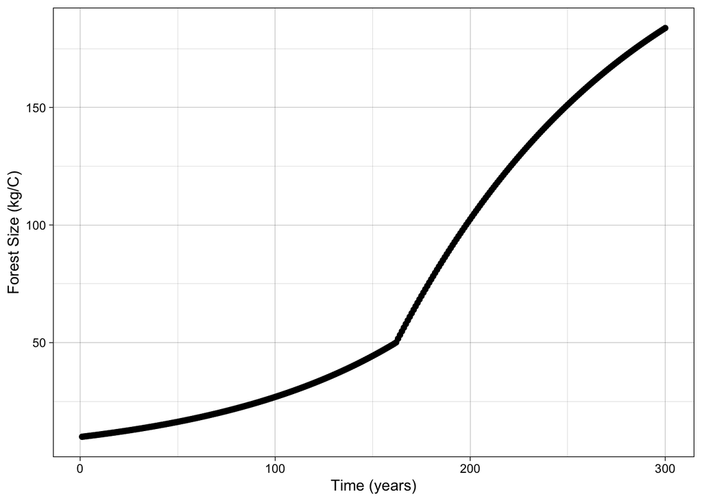

```r
ggplot(result, aes(time, `1`)) +
  geom_point() +
  theme_linedraw() +
  labs(x = "Time (years)", y = "Forest Size (kg/C)")
```

# 4. Run sobol global

Run a sobol global sensitivity analysis (vary all parameters at the same time) that explores how the estimated maximum forest size (e.g maximum of C 300 years), varies with these parameters:

- pre canopy closure growth rate (r)
- post-canopy closure growth rate (g)
- canopy closure threshold and carrying capacity (K)

```r
# generate the sobol parameters; standard deviation of 10% of mean value
np = 2000
K = rnorm(mean=250, sd=250*0.01, n=np)
r = rnorm(mean=0.01, sd=0.01*0.01, n=np)
g = rnorm(mean = 2, sd = 2*0.01, n = np)
X1 = cbind.data.frame(r=r, K=K, g = g)

# repeat for second set of samples
K = rnorm(mean=250, sd=250*0.01, n=np)
r = rnorm(mean=0.01, sd=0.01*0.01, n=np)
g = rnorm(mean = 2, sd = 2*0.01, n = np)
X2 = cbind.data.frame(r=r, K=K, g = g)

# fix any negative values
X1 = X1 %>% map_df(pmax, 0.0)
X2 = X2 %>% map_df(pmax, 0.0)

# run sobol model
sens_P = sobolSalt(model = NULL,X1, X2, nboot = 300)

# add column names
colnames(sens_P$X) = c("r","K", "g")

# gets results for 300 years (evaluating every year)
thresh = 50
simtimes = seq(from=1, to=300)
parms = list(r=sens_P$X[1,"r"],
             K=sens_P$X[1,"K"],
             g=sens_P$X[1,"g"])

# run ode solver
result = ode(y = Cinitial,
             times = simtimes,
             func = dforestgrowth, # growth function
             parms = parms,
             thresh = thresh)

result = as.data.frame(result)

# rename the column names
colnames(result)=c("time","C")
```

Compute metrics and wrapper functions

```r
# turn computing our metrics into a function
compute_metrics = function(result, thresh) {

  maxgrowth = max(result$C)

  idx = which(result$C > thresh)[1] # select first year above threshold
  idx = ifelse(is.na(idx), # if no results from greater than threshold
               length(result$C), # set index to the length of results
               idx) # other wise keep

  threshyear = result$time[idx]

return(list(maxgrowth=maxgrowth, threshyear=threshyear))
}
```

```r
# try it on our first parameter set
p_wrapper = function(r, K, g, Cinitial, simtimes, odefunc, metricfunc, thresh) {
    parms = list(r=r, K=K, g=g)
    result = ode(y=Cinitial,
                 times=simtimes,
                 func=odefunc,
                 parms=parms,
                 thresh = thresh)
    colnames(result)=c("time","C")
  # get metrics
  metrics=metricfunc(as.data.frame(result), thresh=100)
  return(metrics)
}
```

Apply wrapper, growth function, and compute metrics

```r
all = as.data.frame(sens_P$X) %>%
  pmap(p_wrapper,
       thresh=50,
       Cinitial=Cinitial,
       simtimes=simtimes,
       odefunc=dforestgrowth,
       metricfunc=compute_metrics)

# extract results from all into a data frame
allres = all %>%
  map_dfr(`[`,c("maxgrowth","threshyear"))
```

# 5. Graph results of sensitivity analysis as a box plot of maximum forest size and record the two Sobol indices (S and T).

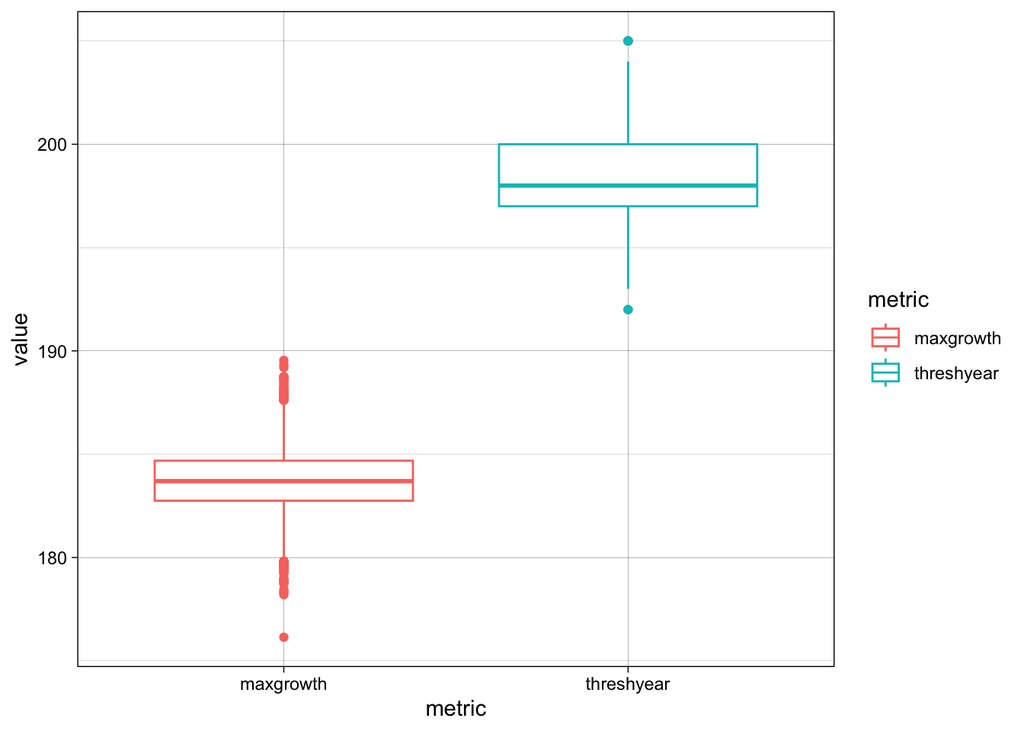

```r
# Boxplots
tmp = allres %>%
  pivot_longer(cols=everything(),
               names_to="metric",
               values_to="value")

ggplot(tmp, aes(metric, value, color = metric)) +
  geom_boxplot() +
  theme_linedraw()
```

```r
# Get sobol indices ----
sens_P_maxgrowth = sensitivity::tell(sens_P,
                                  allres$maxgrowth)

# first-order indices (main effect without co-variance)
rownames(sens_P_maxgrowth$S)=c("r","K", "g")
sens_P_maxgrowth$S
```

```
##    original          bias std. error min. c.i. max. c.i.
## r 0.3347665 -0.0001677829 0.01891297 0.2975917 0.3750659
## K 0.4115009 -0.0016740758 0.01761880 0.3777573 0.4461069
## g 0.2432088 -0.0015984861 0.02050543 0.2023143 0.2907561
```

```r
# total sensitivity index -note that this partitions the output variance
rownames(sens_P_maxgrowth$T)=c("r","K", "g")
sens_P_maxgrowth$T
```

```
##    original         bias  std. error min. c.i. max. c.i.
## r 0.3411948 0.0009633611 0.012681206 0.3135398 0.3652445
## K 0.4220765 0.0001448320 0.014219430 0.3929952 0.4519976
## g 0.2464868 0.0002866520 0.009415981 0.2264074 0.2666693
```

```r
# max year ----
sens_P_threshyear = sensitivity::tell(sens_P,allres$threshyear)
# first-order indices (main effect without co-variance)
rownames(sens_P_threshyear$S)=c("r","K", "g")
sens_P_threshyear$S
```

```
##     original          bias  std. error     min. c.i.  max. c.i.
## r 0.91890784 -6.907865e-04 0.003500856  0.9125156081 0.92670967
## K 0.02113693  7.261562e-04 0.022386873 -0.0247050168 0.06226405
## g 0.04270367  8.532034e-05 0.022607822 -0.0004189975 0.08805812
```

```r
# total sensitivity index -note that this partitions the output variance - so values sum to 1
rownames(sens_P_threshyear$T)=c("r","K", "g")
sens_P_threshyear$T
```

```
##     original          bias  std. error  min. c.i.  max. c.i.
## r 0.94532232 -0.0010665004 0.021679603 0.90788897 0.98990974
## K 0.03173452  0.0001945096 0.001800100 0.02787518 0.03479401
## g 0.07888356  0.0002616988 0.003361971 0.07190567 0.08432661
```

# 6. Discuss meaning of results of simulation (For example think about how what parameters climate change might influence).

Based on the sensitivity metrics, the max growth is most sensitive to the carrying capacity, but is also very affected by the exponential growth rates and then the linear growth rate. The max growth being most affected by carrying capacity could be amplified by changing environmental factors. For example, if a forest under a new climate regime reaches its carrying capacity much slower or faster this would impact its growth rates and ability to meet canopy closure thresh holds. This could also be impacted by the forest community. If climate factors created increased competition levels growth rates could be impacted.